# Exploring Ford Go Bikes Usage In San Francisco

## By Ming Ting

```python
import pandas as pd
import numpy as np
import datetime as dt
from matplotlib import pyplot as plt
import seaborn as sb
import matplotlib as mpl
%matplotlib inline
```

# Gather and Assess

```python
df = pd.read_csv('201902-fordgobike-tripdata.csv')
```

```python
#Assess columns, number of rows, and data types
df.info()
```

```
<class 'pandas.core.frame.DataFrame'>
RangeIndex: 183412 entries, 0 to 183411
Data columns (total 16 columns):
 #   Column                   Non-Null Count   Dtype
---  ------                   --------------   -----
 0   duration_sec             183412 non-null  int64
 1   start_time               183412 non-null  object
 2   end_time                 183412 non-null  object
 3   start_station_id         183215 non-null  float64
 4   start_station_name       183215 non-null  object
 5   start_station_latitude   183412 non-null  float64
 6   start_station_longitude  183412 non-null  float64
 7   end_station_id           183215 non-null  float64
 8   end_station_name         183215 non-null  object
 9   end_station_latitude     183412 non-null  float64
 10  end_station_longitude    183412 non-null  float64
 11  bike_id                  183412 non-null  int64
 12  user_type                183412 non-null  object
 13  member_birth_year        175147 non-null  float64
 14  member_gender            175147 non-null  object
 15  bike_share_for_all_trip  183412 non-null  object
dtypes: float64(7), int64(2), object(7)
memory usage: 22.4+ MB
```

```python
#view statistics of all columns
df.describe()
```

|  | duration_sec | start_station_id | start_station_latitude | start_station_longitude | end_station_id | end_station_latitude | end_station_longitude | bike_id | member_birth_year |
| --- | --- | --- | --- | --- | --- | --- | --- | --- | --- |
| count | 183412.000000 | 183215.000000 | 183412.000000 | 183412.000000 | 183215.000000 | 183412.000000 | 183412.000000 | 183412.000000 | 175147.000000 |
| mean | 726.078435 | 138.590427 | 37.771223 | -122.352664 | 136.249123 | 37.771427 | -122.352250 | 4472.906375 | 1984.806437 |
| std | 1794.389780 | 111.778864 | 0.099581 | 0.117097 | 111.515131 | 0.099490 | 0.116673 | 1664.383394 | 10.116689 |
| min | 61.000000 | 3.000000 | 37.317298 | -122.453704 | 3.000000 | 37.317298 | -122.453704 | 11.000000 | 1878.000000 |
| 25% | 325.000000 | 47.000000 | 37.770083 | -122.412408 | 44.000000 | 37.770407 | -122.411726 | 3777.000000 | 1980.000000 |
| 50% | 514.000000 | 104.000000 | 37.780760 | -122.398285 | 100.000000 | 37.781010 | -122.398279 | 4958.000000 | 1987.000000 |
| 75% | 796.000000 | 239.000000 | 37.797280 | -122.286533 | 235.000000 | 37.797320 | -122.288045 | 5502.000000 | 1992.000000 |
| max | 85444.000000 | 398.000000 | 37.880222 | -121.874119 | 398.000000 | 37.880222 | -121.874119 | 6645.000000 | 2001.000000 |

```python
#view dataset sample
df.head(20)
```

|  | duration_sec | start_time | end_time | start_station_id | start_station_name | start_station_latitude | start_station_longitude | end_station_id | end_station_name | end_station_latitude | end_station_longitude | bike_id | user_type | member_birth_year | member_gender | bike_share_for_all_trip |
| --- | --- | --- | --- | --- | --- | --- | --- | --- | --- | --- | --- | --- | --- | --- | --- | --- |
| 0 | 52185 | 2019-02-28 17:32:10.1450 | 2019-03-01 08:01:55.9750 | 21.0 | Montgomery St BART Station (Market St at 2nd St) | 37.789625 | -122.400811 | 13.0 | Commercial St at Montgomery St | 37.794231 | -122.402923 | 4902 | Customer | 1984.0 | Male | No |
| 1 | 42521 | 2019-02-28 18:53:21.7890 | 2019-03-01 06:42:03.0560 | 23.0 | The Embarcadero at Steuart St | 37.791464 | -122.391034 | 81.0 | Berry St at 4th St | 37.775880 | -122.393170 | 2535 | Customer | NaN | NaN | No |
| 2 | 61854 | 2019-02-28 12:13:13.2180 | 2019-03-01 05:24:08.1460 | 86.0 | Market St at Dolores St | 37.769305 | -122.426826 | 3.0 | Powell St BART Station (Market St at 4th St) | 37.786375 | -122.404904 | 5905 | Customer | 1972.0 | Male | No |
| 3 | 36490 | 2019-02-28 17:54:26.0100 | 2019-03-01 04:02:36.8420 | 375.0 | Grove St at Masonic Ave | 37.774836 | -122.446546 | 70.0 | Central Ave at Fell St | 37.773311 | -122.444293 | 6638 | Subscriber | 1989.0 | Other | No |
| 4 | 1585 | 2019-02-28 23:54:18.5490 | 2019-03-01 00:20:44.0740 | 7.0 | Frank H Ogawa Plaza | 37.804562 | -122.271738 | 222.0 | 10th Ave at E 15th St | 37.792714 | -122.248780 | 4898 | Subscriber | 1974.0 | Male | Yes |
| 5 | 1793 | 2019-02-28 23:49:58.6320 | 2019-03-01 00:19:51.7600 | 93.0 | 4th St at Mission Bay Blvd S | 37.770407 | -122.391198 | 323.0 | Broadway at Kearny | 37.798014 | -122.405950 | 5200 | Subscriber | 1959.0 | Male | No |
| 6 | 1147 | 2019-02-28 23:55:35.1040 | 2019-03-01 00:14:42.5880 | 300.0 | Palm St at Willow St | 37.317298 | -121.884995 | 312.0 | San Jose Diridon Station | 37.329732 | -121.901782 | 3803 | Subscriber | 1983.0 | Female | No |
| 7 | 1615 | 2019-02-28 23:41:06.7660 | 2019-03-01 00:08:02.7560 | 10.0 | Washington St at Kearny St | 37.795393 | -122.404770 | 127.0 | Valencia St at 21st St | 37.756708 | -122.421025 | 6329 | Subscriber | 1989.0 | Male | No |
| 8 | 1570 | 2019-02-28 23:41:48.7900 | 2019-03-01 00:07:59.7150 | 10.0 | Washington St at Kearny St | 37.795393 | -122.404770 | 127.0 | Valencia St at 21st St | 37.756708 | -122.421025 | 6548 | Subscriber | 1988.0 | Other | No |
| 9 | 1049 | 2019-02-28 23:49:47.6990 | 2019-03-01 00:07:17.0250 | 19.0 | Post St at Kearny St | 37.788975 | -122.403452 | 121.0 | Mission Playground | 37.759210 | -122.421339 | 6488 | Subscriber | 1992.0 | Male | No |
| 10 | 458 | 2019-02-28 23:57:57.2110 | 2019-03-01 00:05:35.4350 | 370.0 | Jones St at Post St | 37.787327 | -122.413278 | 43.0 | San Francisco Public Library (Grove St at Hyde... | 37.778768 | -122.415929 | 5318 | Subscriber | 1996.0 | Female | Yes |
| 11 | 506 | 2019-02-28 23:56:55.5400 | 2019-03-01 00:05:21.7330 | 44.0 | Civic Center/UN Plaza BART Station (Market St ... | 37.781074 | -122.411738 | 343.0 | Bryant St at 2nd St | 37.783172 | -122.393572 | 5848 | Subscriber | 1993.0 | Male | No |
| 12 | 1176 | 2019-02-28 23:45:12.6510 | 2019-03-01 00:04:49.1840 | 127.0 | Valencia St at 21st St | 37.756708 | -122.421025 | 323.0 | Broadway at Kearny | 37.798014 | -122.405950 | 5328 | Customer | 1990.0 | Male | No |
| 13 | 915 | 2019-02-28 23:49:06.0620 | 2019-03-01 00:04:21.8670 | 252.0 | Channing Way at Shattuck Ave | 37.865847 | -122.267443 | 244.0 | Shattuck Ave at Hearst Ave | 37.873676 | -122.268487 | 5101 | Subscriber | NaN | NaN | No |
| 14 | 395 | 2019-02-28 23:56:26.8480 | 2019-03-01 00:03:01.9470 | 243.0 | Bancroft Way at College Ave | 37.869360 | -122.254337 | 252.0 | Channing Way at Shattuck Ave | 37.865847 | -122.267443 | 4786 | Subscriber | 1988.0 | Male | No |
| 15 | 208 | 2019-02-28 23:59:18.5480 | 2019-03-01 00:02:47.2280 | 349.0 | Howard St at Mary St | 37.781010 | -122.405666 | 60.0 | 8th St at Ringold St | 37.774520 | -122.409449 | 6361 | Subscriber | 1993.0 | Male | Yes |
| 16 | 548 | 2019-02-28 23:50:41.6070 | 2019-02-28 23:59:49.9530 | 131.0 | 22nd St at Dolores St | 37.755000 | -122.425728 | 71.0 | Broderick St at Oak St | 37.773063 | -122.439078 | 6572 | Subscriber | 1981.0 | Male | No |
| 17 | 674 | 2019-02-28 23:48:25.0950 | 2019-02-28 23:59:40.0920 | 74.0 | Laguna St at Hayes St | 37.776435 | -122.426244 | 336.0 | Potrero Ave and Mariposa St | 37.763281 | -122.407377 | 5343 | Subscriber | 1975.0 | Male | No |
| 18 | 557 | 2019-02-28 23:49:01.8510 | 2019-02-28 23:58:19.8090 | 321.0 | 5th St at Folsom | 37.780146 | -122.403071 | 75.0 | Market St at Franklin St | 37.773793 | -122.421239 | 5854 | Subscriber | 1990.0 | Male | No |
| 19 | 874 | 2019-02-28 23:43:05.1830 | 2019-02-28 23:57:39.7960 | 180.0 | Telegraph Ave at 23rd St | 37.812678 | -122.268773 | 180.0 | Telegraph Ave at 23rd St | 37.812678 | -122.268773 | 5629 | Customer | 1978.0 | Male | No |

```python
#check for null data, the ones with nulls wouldn't affect this project's analysis
df.isnull().sum()
```

```
duration_sec                  0
start_time                    0
end_time                      0
start_station_id            197
start_station_name          197
start_station_latitude        0
start_station_longitude       0
end_station_id              197
end_station_name            197
end_station_latitude          0
end_station_longitude         0
bike_id                       0
user_type                     0
member_birth_year          8265
member_gender              8265
bike_share_for_all_trip       0
dtype: int64
```

```python
#check if there are duplicate rows, there are none
df.duplicated().sum()
```

```
0
```

```python
#check user_type column
df['user_type'].value_counts()
```

```
Subscriber    163544
Customer       19868
Name: user_type, dtype: int64
```

```python
#check values of categorical variable of member_gender
df['member_gender'].value_counts()
```

```
Male      130651
Female     40844
Other       3652
Name: member_gender, dtype: int64
```

```python
#check values of categorical variable of 'bike_share_for_all_trip'
df['bike_share_for_all_trip'].value_counts()
```

```
No     166053
Yes     17359
Name: bike_share_for_all_trip, dtype: int64
```

# Clean

```python
#create copy of original dataset
bikes = df.copy()
```

### Change formats and create new columns

```python
#change to datetime format
bikes['start_time'] = pd.to_datetime(bikes['start_time'])
bikes['end_time'] = pd.to_datetime(bikes['end_time'])

#extract date, hour, day of week, and day from start_time
bikes['start_date'] = bikes['start_time'].dt.strftime('%Y-%m-%d')
bikes['start_hour'] = bikes['start_time'].dt.hour
bikes['start_day_of_week'] = bikes['start_time'].dt.strftime('%A')
bikes['start_day'] = bikes['start_time'].dt.day.astype(int)

#change id's to string
bikes['start_station_id'] = bikes['start_station_id'].astype('str')
bikes['end_station_id'] = bikes['end_station_id'].astype('str')

#change to categorical
bikes['user_type'] = bikes['user_type'].astype('category')
bikes['member_gender'] = bikes['member_gender'].astype('category')
bikes['bike_share_for_all_trip'] = bikes['bike_share_for_all_trip'].astype('category')

#create new column of duration in minutes
bikes['duration_min'] = bikes['duration_sec']/60

#create new column for age of members
bikes['member_age'] = 2019 - bikes['member_birth_year']
```

```python
#visually assess bikes dataset after cleaning
bikes.info()
```

[output not shown]

### member_age outlier and create age group

```python
#There is an outlier as someone is 141 years old
bikes['member_age'].describe()
```

```
count    175147.000000
mean         34.193563
std          10.116689
min          18.000000
25%          27.000000
50%          32.000000
75%          39.000000
max         141.000000
Name: member_age, dtype: float64
```

```python
#95% of users are 55 years old and below, so thats where I will set the max
bikes['member_age'].describe(percentiles = [ .95])
```

```
count    175147.000000
mean         34.193563
std          10.116689
min          18.000000
50%          32.000000
95%          55.000000
max         141.000000
Name: member_age, dtype: float64
```

```python
#Select only the dataset where member_age is 55 or below
bikes = bikes[bikes['member_age']<=55]
```

```python
#create age groups
bikes['member_age_groups'] = bikes['member_age'].apply(lambda x:
                                                    '1 - 15' if 1<x<=15.0
                                                  else '15 - 25 years old' if 15.1<x<=25.0
                                                  else '25 - 35 years old' if 25.1<x<=35.0
                                                  else '35 - 45 years old' if 35.1<x<=45.0
                                                  else '45 - 55 years old' if 45.1<x<=55.0
                                                  else x)
```

```python
#check new column's values
bikes['member_age_groups'].value_counts()
```

[output not shown]

### duration_min outlier

```python
#There is an outlier where someone rode 1409 minutes
bikes['duration_min'].describe()
```

[output not shown]

```python
#95% of the rides are 25 minutes long at most, so thats where I will set the max
bikes['duration_min'].describe(percentiles = [ .95])
```

```
count    167258.000000
mean         11.697078
std          27.430907
min           1.016667
50%           8.483333
95%          25.300000
max        1409.133333
Name: duration_min, dtype: float64
```

```python
#Select only the dataset where duration is 25.3 minutes and below
bikes = bikes[bikes['duration_min']<=25.3]
```

```python
#check new column's stats
bikes['duration_min'].describe()
```

```
count    158905.000000
mean          9.188944
std           5.107661
min           1.016667
25%           5.233333
50%           8.133333
75%          12.200000
max          25.300000
Name: duration_min, dtype: float64
```

## What is the structure of your dataset?

The dataset contains 183412 rides from February of 2019 in the San Francisco area. Originally, there are 16 columns with data types of int, object, and float. The columns represent data such as: ride duration, start and end time, station name, id and location, bike id, whether user is a subscriber or customer, member birth year and gender.

-age of users -age group of users -ride duration in minutes

## What is/are the main features of interest in your dataset?

I am interested in finding out about: -What days and hours are most popular for riders? -What is the difference in riding patterns between different categorical groups?

## What features in the dataset do you think will help support your investigation into your feature(s) of interest?

I think the columns such as duration, start time, week day, gender, user type and age will all be useful in finding interesting things from this dataset.

# Univariate Exploration

## What is the distribution of the age of riders?

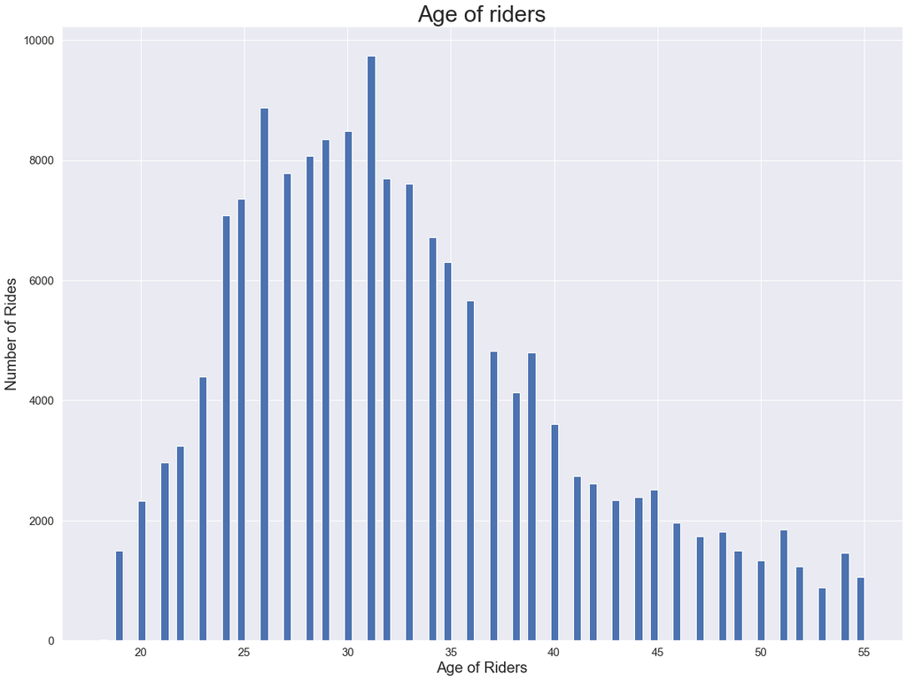

```python
#age of riders

plt.figure(figsize=[20,15])
plt.hist(bikes['member_age'], bins=100)

plt.xlabel('Age of Riders', size = 20)
plt.ylabel('Number of Rides', size = 20)

plt.xticks(size =15)
plt.yticks(size =15)

plt.title('Age of riders', size =30)
plt.show()
```

#### Most of the riders are definitely between 24 to 38, as they represent the largest peak in the histogram. Ages from 18 to 24 and 40 to 55 of riders take significantly less rides on these bikes. My interpretation is that people of about age 25 to 35 are in their prime working years but still young and energetic enough to take a bicycle to work. People who are younger tend not to have full time jobs and people who are older have less energy to ride bikes to work.

## Which days of the week are the bikes most used?

[figure not shown]

```python
#days of the week

x = bikes['start_day_of_week'].unique()
y = bikes['start_day_of_week'].value_counts()

plt.figure(figsize=[20,15])
plt.bar(x,y, color ='orange')

plt.xlabel('Day of Week', size = 20)
plt.ylabel('Number of Riders', size = 20)

plt.xticks(size =15)
plt.yticks(size =15)

plt.title('Rides on each day of the week', size =30)
plt.show()
```

## What are the durations of rides?

[figure not shown]

```python
#duration in minutes

bikes['duration_min'].value_counts()

plt.figure(figsize=[20,15])
uv1 = plt.hist(bikes['duration_min'].value_counts(), bins=50)

plt.xlabel('Duration in minutes', size=20)
plt.ylabel('Number of Riders', size=20)

plt.xticks(size =15)
plt.yticks(size =15)


plt.title('Duration of rides in minutes', size =30)
plt.show()
```

## Of all riders, how many are subscribers and how many are users?

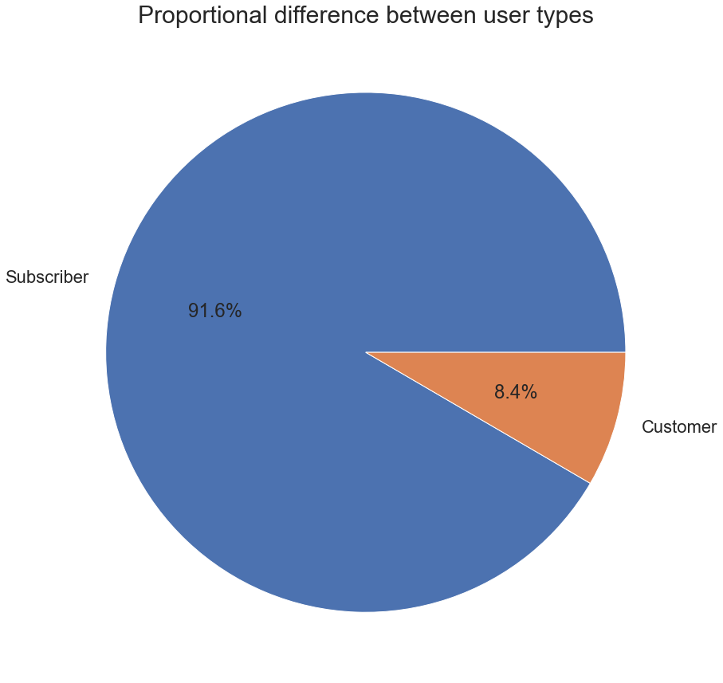

```python
#user types

user_kinds = bikes['user_type'].value_counts()
plt.figure(figsize=[20,15])
uv2 = plt.pie(user_kinds, labels=user_kinds.index, autopct='%1.1f%%')

mpl.rcParams['font.size'] = 18.0

plt.title('Proportional difference between user types', size =30)
plt.show()
```

#### 91.6 percent of the users are subscribers, and 8.4% are customers. My interpretation is that commuting by bike share is very popular and convenient in San Francisco, as being a subscriber probably has it benefits if it is used often.

## Of all riders, what are the proportions between genders?

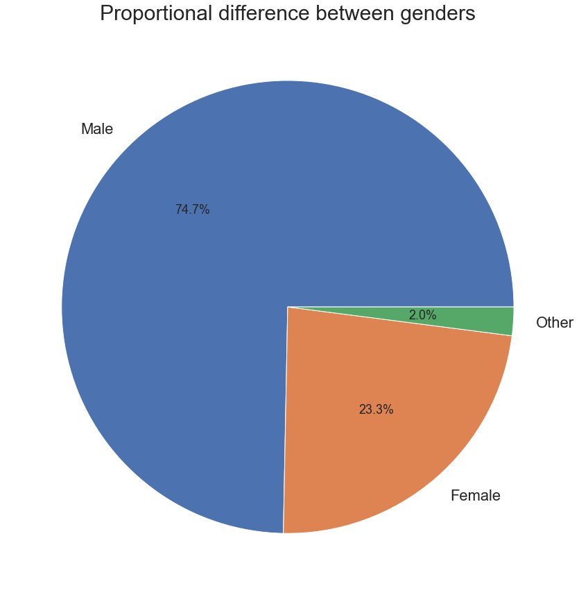

```python
#genders

genders = bikes['member_gender'].value_counts()
plt.figure(figsize=[20,15])
uv3 = plt.pie(genders, labels=genders.index, autopct='%1.1f%%')

mpl.rcParams['font.size'] = 18.0

plt.title('Proportional difference between genders', size =30)
plt.show()
```

#### 74.7% are male, while 23.3% are female, with 2% being other. My interpretation is that males are physically stronger and are able to ride the bikes up the hills of San Francisco. Females are also more prone to danger so they will choose to take other safer forms of transportation.

## Of all riders, what are the proportions between age groups?

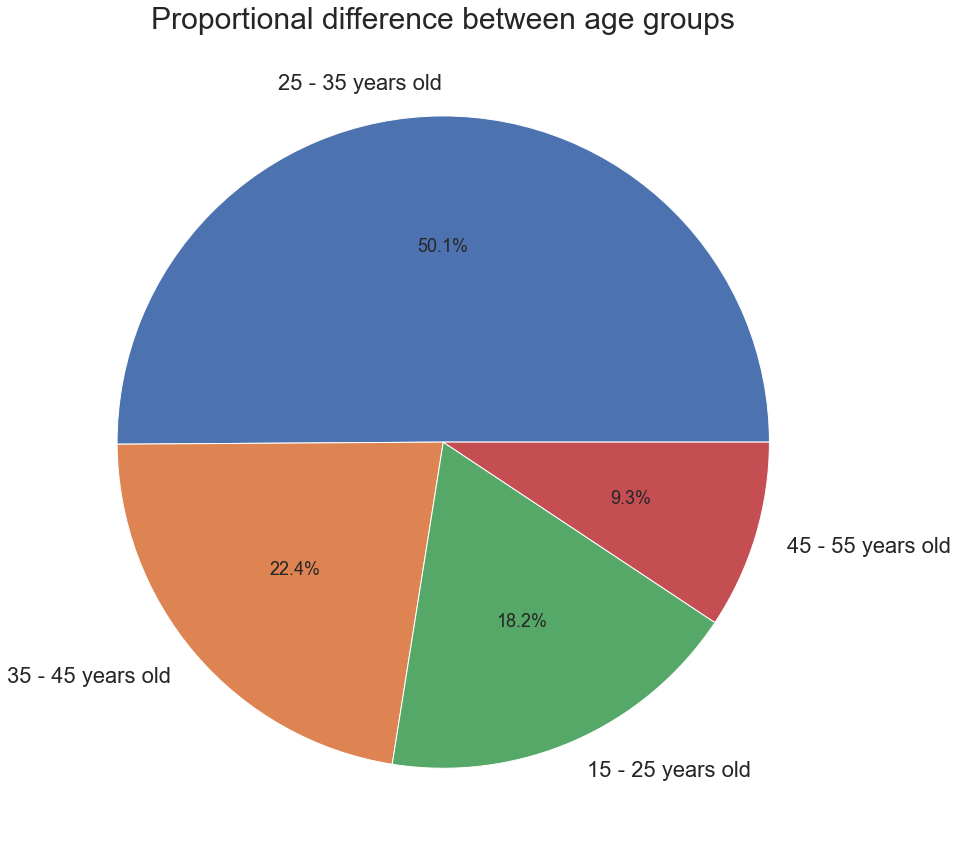

```python
#age groups

age_groups = bikes['member_age_groups'].value_counts()
plt.figure(figsize=[20,15])
uv4 = plt.pie(age_groups, labels=age_groups.index, autopct='%1.1f%%')

mpl.rcParams['font.size'] = 18.0

plt.title('Proportional difference between age groups', size =30)
plt.show()
```

#### 50.1% are 25-35 years old, 22.4% are 35-45 years old, 18.2% are 15-25 years old, and 9.3% are 44-55 years. My interpretation is that the 2 largest groups of 25-35 and 35-45 are in their prime working years and they have the energy to ride a bicycle to work. 15-25 year olds tend not to have full time jobs yet, and 45-55 year olds have less energy to ride bikes.

## Discuss the distribution(s) of your variable(s) of interest. Were there any unusual points? Did you need to perform any transformations?

#### The main variables of interest are ride duration, day of the week, gender, and user type. I did not find any distribution unusal as they are met my expectations.

## Of the features you investigated, were there any unusual distributions? Did you perform any operations on the data to tidy, adjust, or change the form of the data? If so, why did you do this?

#### The main change thing I did was filter out the outliers of age, as someone who was 141 was skewing the distribution. 95% of riders were below 55 years old. So I grouped the ages accordingly from 15 to 55 years old in 4 groups.

# Bivariate Exploration

## What is the duration difference for rides between genders?

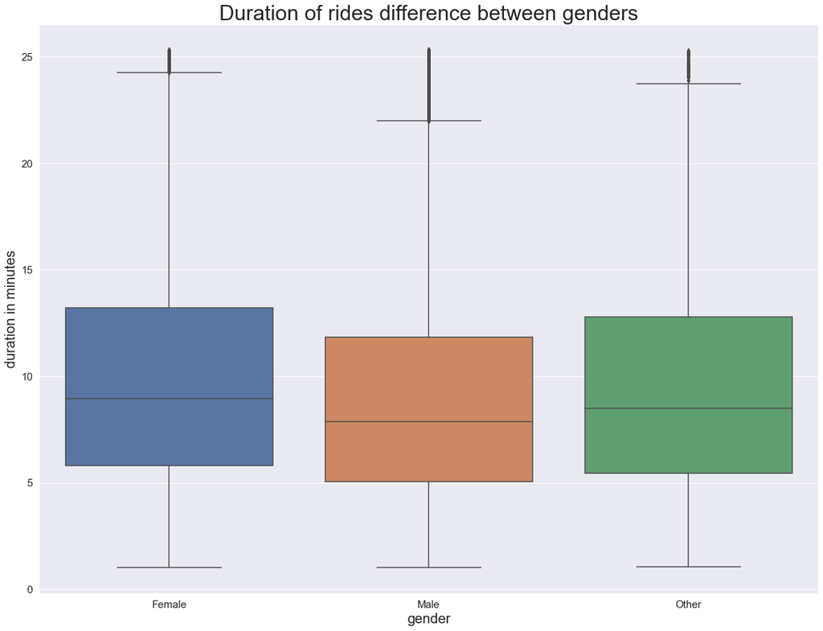

```python
#duration and gender

plt.figure(figsize=[20,15])
bv1 = sb.boxplot(data=bikes, x = bikes['member_gender'], y = bikes['duration_min'])

plt.xticks(size =15)
plt.yticks(size =15)

plt.xlabel('gender', size=20)
plt.ylabel('duration in minutes', size=20)

plt.title('Duration of rides difference between genders', size =30)
plt.show()
```

#### The duration average, min, and max are similar between female and other, while males are slightly lower. My interpretation is that males tend to be physically stronger so they are able to ride faster, thus arriving at their destination at a lower time.

## What is the duration difference for rides between subscribers and customers?

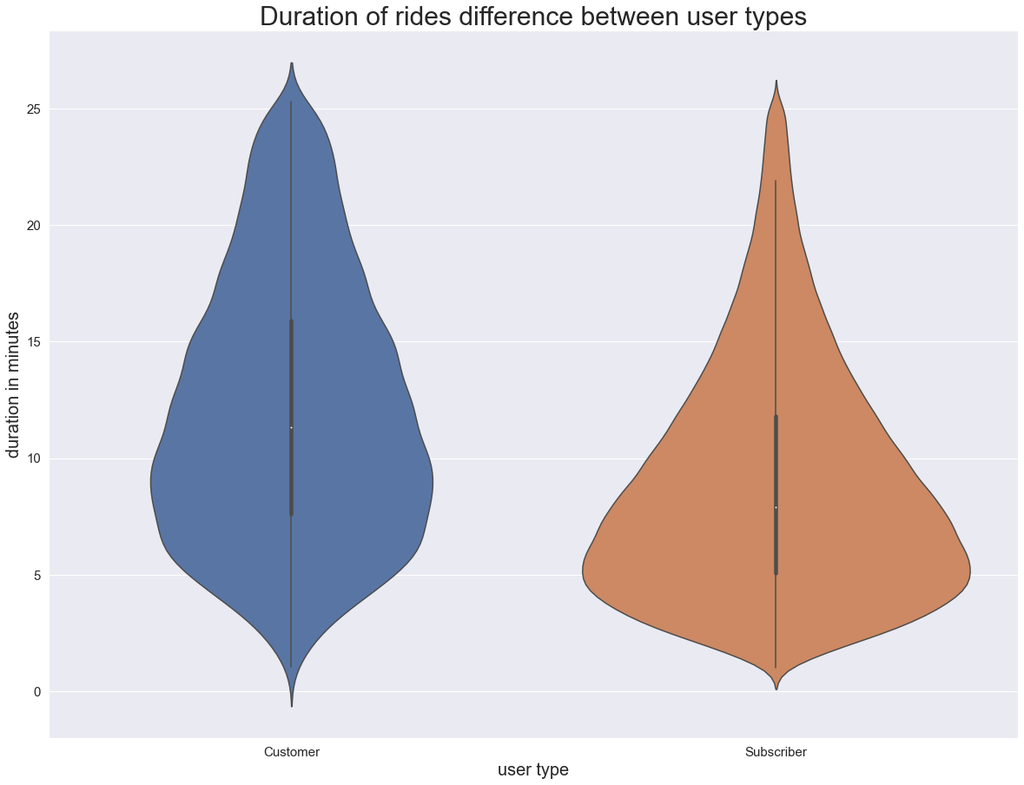

```python
#duration and user type
plt.figure(figsize=[20,15])
bv2 = sb.violinplot(data=bikes, x = bikes['user_type'], y = bikes['duration_min'])

plt.xticks(size =15)
plt.yticks(size =15)

plt.xlabel('user type', size=20)
plt.ylabel('duration in minutes', size=20)

plt.title('Duration of rides difference between user types', size =30)
plt.show()
```

#### There are alot more subscribers with a ride duration within 3 to 10 minutes than the customers. My interpretation is that subscribers tend to use these bikes for commuting while customers tend to use them for fun. Therefore, it is feasible for most subscribers to only have a 3 to 10 minute commute to work, as anything higher would be less feasible and cause fatigue.

# What is the duration difference for rides between age groups?

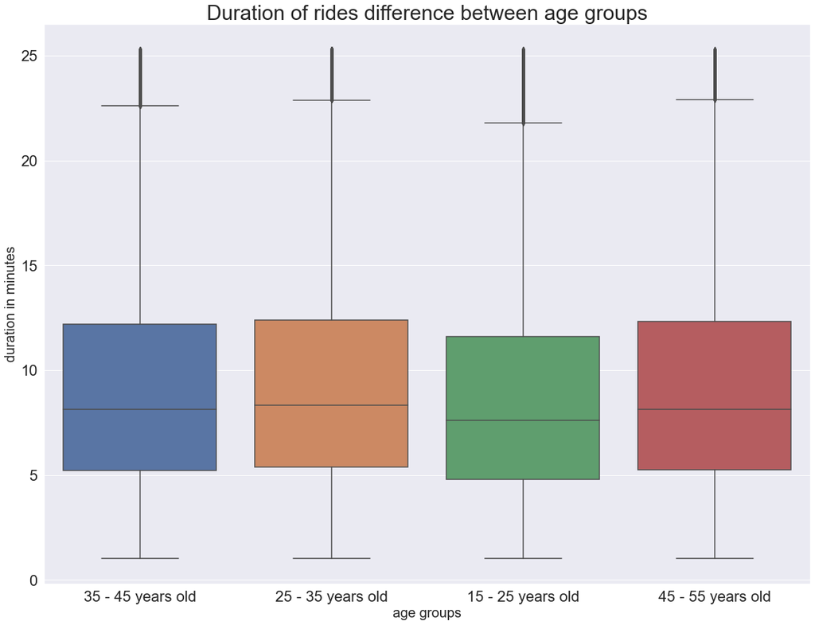

```python
#age groups and duration

plt.figure(figsize=[20,15])
bv3 = sb.boxplot(data=bikes, x = bikes['member_age_groups'], y = bikes['duration_min'])

plt.xlabel('age groups', size=20)
plt.ylabel('duration in minutes', size=20)

plt.title('Duration of rides difference between age groups', size =30)
plt.show()
```

#### The average, maximum and minimum are the ride duration are similar between the 35-45, 25-35, and 45-55 age groups. While the 15-25 age group is slightly lower. My interpretation is that the 15-25 are not using these rides for commute, but for leisure.

## Talk about some of the relationships you observed in this part of the investigation. How did the feature(s) of interest vary with other features in the dataset?

#### The main difference that I observed was the duration between subscribers and customers. There were alot more subscribers within the 2 to 10 minute mark with alot less above 10 minutes when compared to customers who were more even in their ride durations. The other small difference is that males have a lower riding duration than females, my interpretation is that males are stronger so they ride faster and require less time to reach their destination.

## Did you observe any interesting relationships between the other features (not the main feature(s) of interest)?

#### I did not really see any other interesting relationships, as the age groups are all very similar in their ride durations.

# Multivariate Exploration

## Do subscribers and users differ in their usage throughout the days of the week?

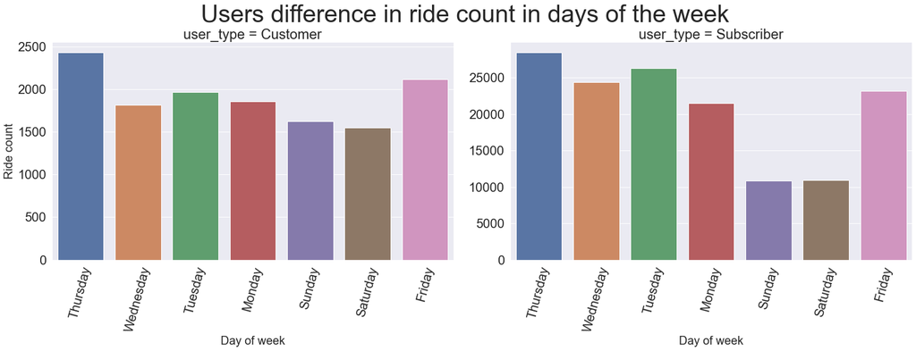

```python
# day_of_week, count, user_type
sb.set( rc = {'figure.figsize' : ( 30, 20 ),
               'axes.labelsize' : 12 })
sb.set(font_scale = 2)

mv1 = sb.catplot(data=bikes, x='start_day_of_week', col="user_type",
                 kind='count', sharey = False, height=7, aspect=11/7)

mv1.set_xticklabels(rotation=75);

mv1.fig.suptitle("Users difference in ride count in days of the week" ,
               fontsize = 'xx-large')
mv1.fig.subplots_adjust( top = 0.85 )

mv1.set_axis_labels( "Day of week" , "Ride count", size =20)


plt.show()
```

#### The days with biggest difference in ratio for customers are Sunday, and Saturday, where they have a more even ratio with the rest of the weekdays when compared to the subscribers, where their ride rate is alot lower when compare to weekdays. My intepretation is that subscribers are commuters who mostly use these bikes in for Monday to Friday for work, and by contrast, will ride them alot less on Sunday and Saturday. Customers are more even in their usage throughtout the week as they don't use them for commuting to work but for leisure.

## Do subscribers and customers differ in their riding usage in different hours?

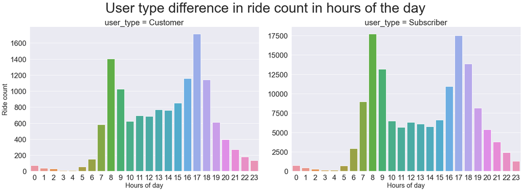

```python
# hours, count, user_type
sb.set(font_scale = 2)

mv2 = sb.catplot(data=bikes, x='start_hour', col="user_type", kind='count',
                 sharey = False, height=8, aspect=11/8)

mv2.fig.suptitle("User type difference in ride count in hours of the day" ,
               fontsize = 'xx-large')

mv2.fig.subplots_adjust( top = 0.85 )

mv2.set_axis_labels( "Hours of day" , "Ride count", size =20)

plt.show()
```

#### 8am is the biggest difference in terms of peak usage between the customers and subscribers. The subscribers have a much high peak at 8 am than the customers. But both groups also has another peak at 5pm. My interpretation is that there are more subscribers than customers who use these bikes for commuting at work, but many customers may also be using these brikes, therefore 8 am is when they start using these bikes, and again at 5pm when they get off work to bike back home.

## Do genders differ in their usage throughout the days of the week?

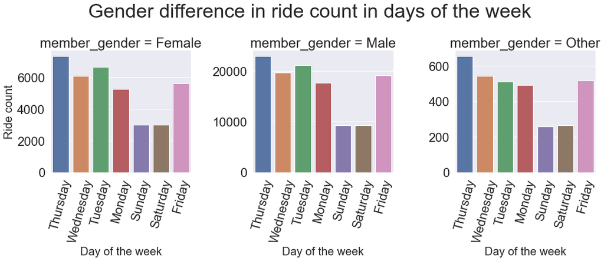

```python
# day_of_week, count, gender
sb.set(font_scale = 2)

mv3 = sb.catplot(data=bikes, x='start_day_of_week', col="member_gender", kind='count',
                  sharey = False)

mv3.fig.suptitle("Gender difference in ride count in days of the week" ,
               fontsize = 'x-large')

mv3.fig.subplots_adjust( top = 0.75 )

mv3.set_xticklabels(rotation=75);

mv3.set_axis_labels( "Day of the week" , "Ride count", size =20)

plt.show()
```

#### Males and females do not differ much in their ride count through the days of the week, as they are both likely use these bikes for commuting to work. The other group varies a bit but it may be due to small sample size.

## Do genders differ in their usage throughout the hours of the day?

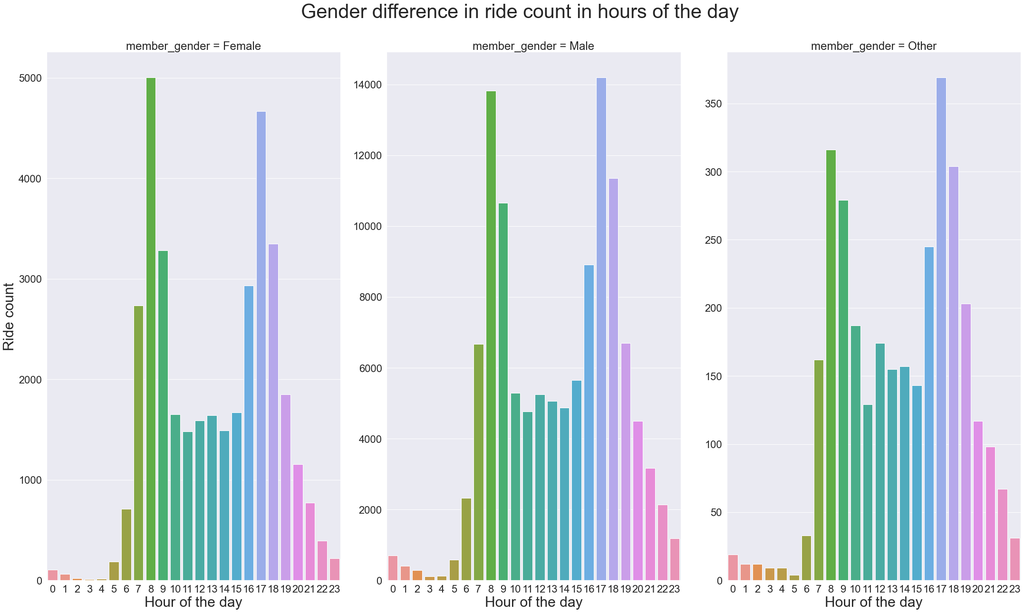

```python
# hours, count, gender
sb.set( rc = {'figure.figsize' : ( 40, 20 ),
               'axes.labelsize' : 12 })
sb.set(font_scale = 2)

mv4 = sb.catplot(data=bikes, x='start_hour', col="member_gender", kind='count', sharey = False,
                height=18, aspect=10/18)

mv4.fig.suptitle("Gender difference in ride count in hours of the day" ,
               fontsize = 'xx-large')

mv4.fig.subplots_adjust( top = 0.9 )

mv4.set_axis_labels( "Hour of the day" , "Ride count", size =30)

#mv4.set_xticklabels(rotation=75);

plt.show()
```

# Do Age groups differ in their duration throughout the days of the week?

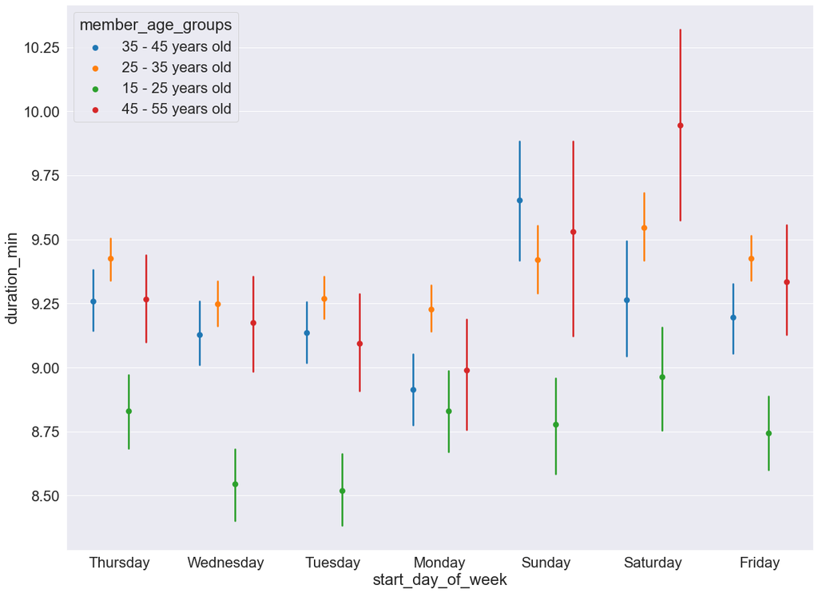

```python
fig = plt.figure(figsize = [20,15])
sb.set(font_scale = 2)
mv5 = sb.pointplot(data = bikes, x = 'start_day_of_week', y = 'duration_min', hue = 'member_age_groups',
           palette = 'tab10', linestyles = '', dodge = 0.5)


plt.show()
```

#### For the age group 35-45 and 25-35, they are the most consistent in their duration for each day of the week, mostly ranging from 9 to 9.5 minutes. 35-45 have a peak average on Sunday, where it is above 9.5 and a minimum average usage on Monday, below 9 minutes. 25-35 have a peak average on Saturdays with above 0.5 while all other days are about equal. 15-25 have the shortest duration on each day of the week with minimum average of 8.5 minutes on Wednesday and Tuesday, and a peak of nearly 9 minutes on Saturday. THe 45-55 age group has a peak in Saturdays with an average duration of almost 10 minutes, witha 2nd peak on Sunday with an average of 9.5 minutes while other days are mostly the same.

# Do Age groups differ in their duration throughout the hours of the day?

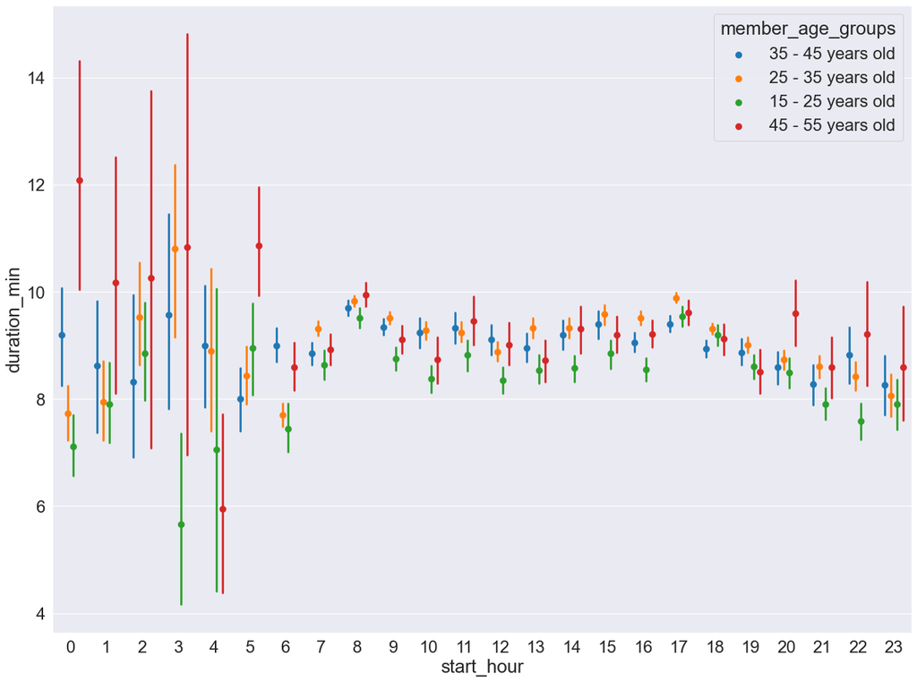

```python
fig = plt.figure(figsize = [20,15])
sb.set(font_scale = 2)
mv6 = sb.pointplot(data = bikes, x = 'start_hour', y = 'duration_min', hue = 'member_age_groups',
           palette = 'tab10', linestyles = '', dodge = 0.5)
```